# blog1

## Simple Linear Regression in Python

In most of the courses at CUNY SPS, including this one, R seems to be the preferred language to use when creating models and doing analysis. Since my first love is Python, this blog will just demonstrate how to create a simple linear regression model using Ski-Kit Learn, Seaborn, and Pandas

First, we'll import our libraries for our model and analysis

```python
import pandas as pd
import numpy as np
import scipy.stats
import matplotlib.pyplot as plt
import seaborn as sns
from sklearn.linear_model import LinearRegression
from sklearn.model_selection import train_test_split
from sklearn import datasets
```

We'll use sklearn's Boston housing dataset. For the purposes of this blog, we'll just look at number of rooms as our independent variable. For the dependent variable, we'll use `MEDV`. A simple description of the dataset is provided below.

```python
b = datasets.load_boston()
print(b.DESCR)
```

```
.. _boston_dataset:

Boston house prices dataset
---------------------------

**Data Set Characteristics:**

    :Number of Instances: 506

    :Number of Attributes: 13 numeric/categorical predictive. Median Value (attribute 14) is usually the target.

    :Attribute Information (in order):
        - CRIM     per capita crime rate by town
        - ZN       proportion of residential land zoned for lots over 25,000 sq.ft.
        - INDUS    proportion of non-retail business acres per town
        - CHAS     Charles River dummy variable (= 1 if tract bounds river; 0 otherwise)
        - NOX      nitric oxides concentration (parts per 10 million)
        - RM       average number of rooms per dwelling
        - AGE      proportion of owner-occupied units built prior to 1940
        - DIS      weighted distances to five Boston employment centres
        - RAD      index of accessibility to radial highways
        - TAX      full-value property-tax rate per $10,000
        - PTRATIO  pupil-teacher ratio by town
        - B        1000(Bk - 0.63)^2 where Bk is the proportion of blacks by town
        - LSTAT    % lower status of the population
        - MEDV     Median value of owner-occupied homes in $1000's

    :Missing Attribute Values: None

    :Creator: Harrison, D. and Rubinfeld, D.L.

This is a copy of UCI ML housing dataset.
https://archive.ics.uci.edu/ml/machine-learning-databases/housing/


This dataset was taken from the StatLib library which is maintained at Carnegie Mellon University.

The Boston house-price data of Harrison, D. and Rubinfeld, D.L. 'Hedonic
prices and the demand for clean air', J. Environ. Economics & Management,
vol.5, 81-102, 1978.   Used in Belsley, Kuh & Welsch, 'Regression diagnostics
...', Wiley, 1980.   N.B. Various transformations are used in the table on
pages 244-261 of the latter.

The Boston house-price data has been used in many machine learning papers that address regression
problems.

.. topic:: References

   - Belsley, Kuh & Welsch, 'Regression diagnostics: Identifying Influential Data and Sources of Collinearity', Wiley, 1980. 244-261.
   - Quinlan,R. (1993). Combining Instance-Based and Model-Based Learning. In Proceedings on the Tenth International Conference of Machine Learning, 236-243, University of Massachusetts, Amherst. Morgan Kaufmann.
```

## Visualizing our model using Seaborn and Scipy

The great thing about Seaborn is that there is a built in function to graph a simple linear regression model over our data. This is accomplished below. Let's first store our data into variables.

#### Loading the data into variables

Sci-kit learn's datasets are stored as numpy arrays. From the overview we saw earlier, we know that the 6th column in our array is the number of rooms. So we can access that data and store that in `x`. Median home value with be stored as `y`.

```python
x = b.data[:,5]
y = b.target
```

Simple enough. Let's plot our data

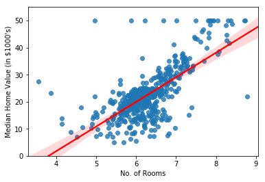

```python
bRM = sns.regplot(x=x, y=y, line_kws={'color':'red'})
bRM.set(ylim=(0, 55),
        xlabel='No. of Rooms',
        ylabel="Median Home Value (in $1000's)")
plt.show()
```

```python
slope, intercept, r_value, p_value, std_err = scipy.stats.linregress(x, y)
r2 = r_value**2

print('Slope: ',slope)
print('Intercept: ',intercept)
print('R-squared: ',r2)
print('p-value',p_value)
print('std-err',std_err)
```

```
Slope:  9.102108981180306
Intercept:  -34.67062077643854
R-squared:  0.48352545599133356
p-value 2.487228871008377e-74
std-err 0.41902656012134054
```

## Creating our model with `sklearn`

Now that we have a nice preliminary visual of our model through seaborn, let's build it with `sklearn`. We'll split our data 80/20, train/split. There are some limits to getting some statistical values using sklearn. In the event that one wants to get statistical values, a combination of `scipy` as demonstrated above and `sklearn` would work as well. Our statistical values here might also be slightly different since we'll be creating a training and test set.

```python
model = LinearRegression()
X_train, X_test, y_train, y_test = train_test_split(x.reshape((-1,1)), #Number of Rooms
                                                    y, #Median Value of home
                                                    test_size=0.2,
                                                    random_state=42)

model.fit(X_train,y_train)
r2 = model.score(X_test,y_test)
intercept = model.intercept_
slope = model.coef_
y_pred = model.predict(X_test)
print('Slope: ',slope)
print('Intercept: ',intercept)
print('R-squared: ',r2)
```

```
Slope:  [9.34830141]
Intercept:  -36.24631889813795
R-squared:  0.3707569232254778
```

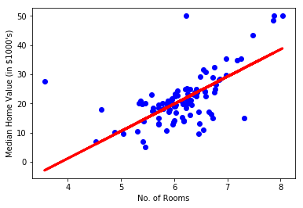

```python
plt.scatter(X_test, y_test,  color='blue')
plt.plot(X_test, y_pred, color='red', linewidth=3)
plt.xlabel('No. of Rooms')
plt.ylabel("Median Home Value (in $1000's)")
plt.show()
```